# WNN analysis of CITE-seq, RNA + ADT

Nasir Mahmood Abbasi, PhD

2024-09-19

**Status: partial reference only.**

This page contains saved UMAP, feature, and modality-weight plots, but the source Seurat object is not included and the analyses have not been rerun. Saved output reports a 28-item PCA cap, a modality-weight name mismatch, and a missing adt_CD90 feature. Treat the embedded plots as references, not as results regenerated from the source shown here.

# 1. load libraries

# 2. Load Seurat Object

```r
  All_samples_Merged
```

```
An object of class Seurat
62625 features across 46976 samples within 6 assays
Active assay: SCT (25901 features, 3000 variable features)
 3 layers present: counts, data, scale.data
 5 other assays present: RNA, ADT, prediction.score.celltype.l1, prediction.score.celltype.l2, prediction.score.celltype.l3
 4 dimensional reductions calculated: pca, umap, integrated_dr, ref.umap
```

# 3. Data PREPERATION

The original source supplied one `RNA.weight` name for two modalities. The saved output says the weights were stored as `SCT.weight` and `ADT.weight`, which the following violin plots use. The source now names both observed columns explicitly. The warning shown in the saved output is from the earlier source, not a regenerated run.

```r
DefaultAssay(All_samples_Merged) <- 'ADT'

VariableFeatures(All_samples_Merged) <- rownames(All_samples_Merged[["ADT"]])

# we will use all ADT features for dimensional reduction
# we set a dimensional reduction name to avoid overwriting the
All_samples_Merged <- NormalizeData(All_samples_Merged, normalization.method = 'CLR', margin = 2) %>%
  ScaleData() %>% RunPCA(reduction.name = 'apca', npcs =28, maxit = 5000)
```

```
Normalizing across cells
```

[output not shown]

[output cut: 46 more lines]

[output not shown]

```
Warning: You're computing too large a percentage of total singular values, use a standard svd instead.Warning: Requested number is larger than the number of available items (28). Setting to 28.Warning: Requested number is larger than the number of available items (28). Setting to 28.Warning: Request…
Positive:  CD5, CD274, TCRab, CD7, CD3, CD28, CD45RO, CD26, CD44, CD62L
       CXCR3, CD127, CD45, CCR8
Negative:  CD25, CD30, CD2, CD95, CD45RA, CD4, CCR6, CCR4, CXCR4, CD40
       CD19, CCR7, PD1, CCR10
PC_ 2
Positive:  CD45, CD44, CD45RO, CD4, CD3, CD40, CCR4, CD45RA, CD26, CD95
       CD2, CD5, CD62L, CD28
Negative:  CD127, CD19, PD1, CCR7, CCR10, CXCR3, CCR8, CCR6, CD7, CD274
       CD30, CXCR4, CD25, TCRab
PC_ 3
Positive:  CD62L, TCRab, CD28, CD3, CD4, CXCR4, CCR7, CD45RA, CD127, CD5
       PD1, CCR4, CD95, CD2
Negative:  CD26, CXCR3, CD45RO, CD274, CD40, CD44, CCR10, CCR6, CD7, CD30
       CD19, CD25, CD45, CCR8
PC_ 4
Positive:  CCR4, CD5, CD274, CD4, CD30, CCR6, CD44, CD28, CD25, CD45RA
       CD19, CCR10, CXCR3, PD1
Negative:  CD40, CD45, CD2, CD62L, CD7, CD26, CXCR4, CCR7, CD127, CD95
       CD45RO, CCR8, CD3, TCRab
PC_ 5
Positive:  CD45RO, CD28, CCR8, CD26, CCR4, PD1, CD4, CCR10, CD40, CD127
       CD19, TCRab, CD2, CCR7
Negative:  CD7, CD45RA, CD5, CD44, CCR6, CXCR3, CXCR4, CD274, CD62L, CD30
       CD3, CD95, CD45, CD25
Warning: Key 'PC_' taken, using 'apca_' instead
```

```r
# Identify multimodal neighbors and graphs on All_samples_Merged.
# Cell-specific modality weights are stored as SCT.weight and ADT.weight, as reported by the saved run.

All_samples_Merged <- FindMultiModalNeighbors(
  All_samples_Merged, reduction.list = list("pca", "apca"),
  dims.list = list(1:30, 1:18), modality.weight.name = c("SCT.weight", "ADT.weight")
)
```

```
Calculating cell-specific modality weights
Finding 20 nearest neighbors for each modality.
```

```
  |                                                  | 0 % ~calculating
  |+++++++++++++++++++++++++                         | 50% ~08s
  |++++++++++++++++++++++++++++++++++++++++++++++++++| 100% elapsed=17s
```

```
Calculating kernel bandwidths
```

```
  |                                                  | 0 % ~calculating
  |+++++++++++++++++++++++++                         | 50% ~01s
  |++++++++++++++++++++++++++++++++++++++++++++++++++| 100% elapsed=02s
```

```
Warning: The number of provided modality.weight.name is not equal to the number of modalities. SCT.weight ADT.weight are used to store the modality weightsFinding multimodal neighbors
```

```
  |                                                  | 0 % ~calculating
  |+++++++++++++++++++++++++                         | 50% ~28s
  |++++++++++++++++++++++++++++++++++++++++++++++++++| 100% elapsed=59s

  |                                                  | 0 % ~calculating
  |+++++++++++++++++++++++++                         | 50% ~01s
  |++++++++++++++++++++++++++++++++++++++++++++++++++| 100% elapsed=02s
```

```
Constructing multimodal KNN graph
Constructing multimodal SNN graph
```

# 4. Visualization RNA+ADT

The saved output reports that `adt_CD90` was not found. The source does not establish a valid replacement feature, so no substitute is inferred. The request and its warning are retained as an unavailable feature example; the plot output has not been regenerated.

[figure not shown]

[figure not shown]

```r
# The saved run reports that adt_CD90 was not found. No replacement is inferred from this source.
p5 <- FeaturePlot(All_samples_Merged, features = c("adt_CD45RA","adt_CD45RO","adt_CD90"),
                  reduction = 'wnn.umap', max.cutoff = 2,
                  cols = c("lightgrey","darkgreen"), ncol = 3)
```

```
Warning: The following features could not be found adt_CD90Warning: The following requested variables were not found: adt_CD90
```

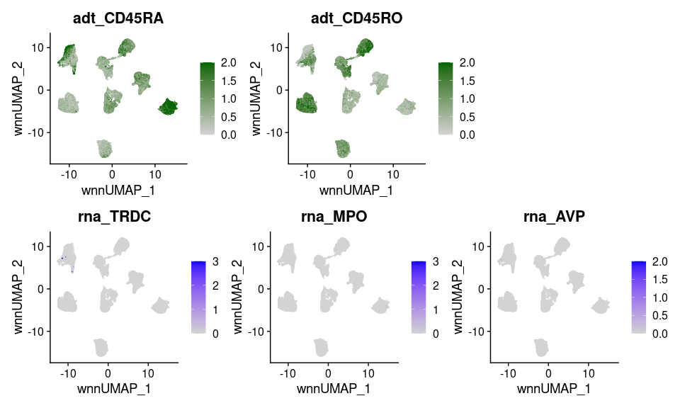

```r
p6 <- FeaturePlot(All_samples_Merged, features = c("rna_TRDC","rna_MPO","rna_AVP"),
                  reduction = 'wnn.umap', max.cutoff = 3, ncol = 3)
p5 / p6
```

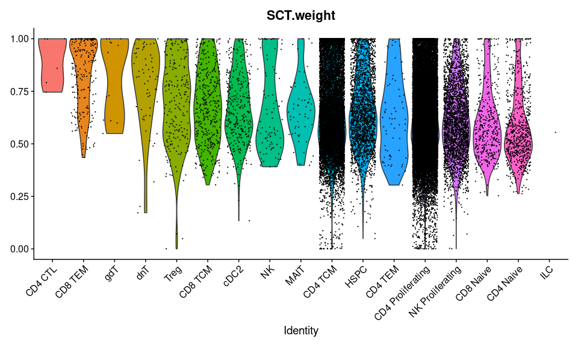

```r
 VlnPlot(All_samples_Merged, features = "SCT.weight", group.by = 'predicted.celltype.l2', sort = TRUE, pt.size = 0.1) +
  NoLegend()
```

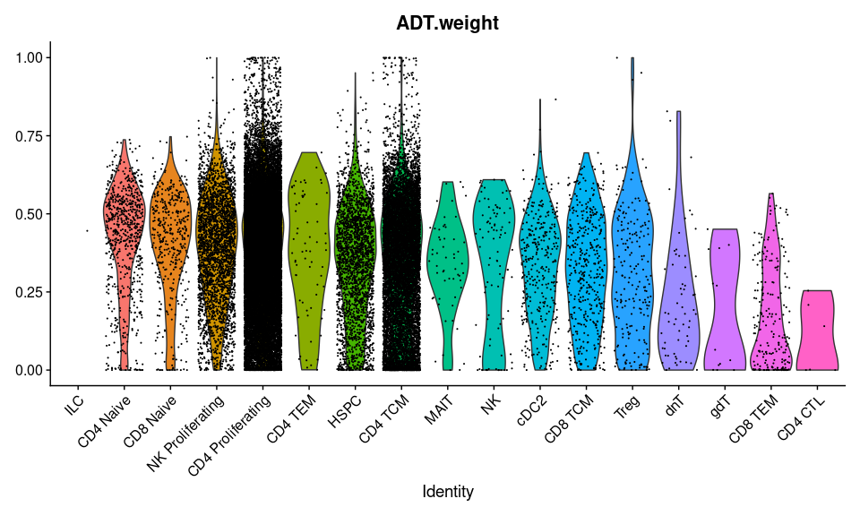

```r
 VlnPlot(All_samples_Merged, features = "ADT.weight", group.by = 'predicted.celltype.l2', sort = TRUE, pt.size = 0.1) +
  NoLegend()
```

# 5. Save the Seurat object as an Robj file

```r
save(All_samples_Merged, file = "../0-imp_OBJ_SS/All_samples_Merged_WNN.Robj")
```